# NASA API Vignette

## Introduction

This vignette has made use of the [NASA Exoplanet Archive](https://exoplanetarchive.ipac.caltech.edu/docs/intro.html), which is operated by the California Institute of Technology, under contract with the National Aeronautics and Space Administration under the Exoplanet Exploration Program.

## Package requirements

To re-create this project in R, users are required to install:

- **[tidyverse](https://www.tidyverse.org/)** - encompasses packages such as `dplyr` for subsetting data and `ggplot2` for creating layered graphics.
- **[httr](https://httr.r-lib.org/)** - supplies the `GET()` function to programmatically retrieve content from NASA Exoplanet Archive’s [TAP service](https://exoplanetarchive.ipac.caltech.edu/docs/TAP/usingTAP.html#examples).
- **[jsonlite](https://cran.r-project.org/web/packages/jsonlite/vignettes/json-aaquickstart.html)** - supplies the `fromJSON()` function to simplify JSON content into an atomic vector.
- **[latex2exp](https://cran.r-project.org/web/packages/latex2exp/vignettes/using-latex2exp.html)** - “an R package that parses and converts LaTeX math formulas to R’s plotmath expressions.” This is useful for labeling masses and radii on plots using [solar system symbols](https://solarsystem.nasa.gov/resources/680/solar-system-symbols/).
- **[ggrepel](https://ggrepel.slowkow.com/)** - eliminate overlapping text labels in the `ggplot2` exoplanet mass-radius diagram.

## Custom functions

### annualExoDiscoveries()

This custom function programmatically retrieves data from the [NASA Exoplanet Archive’s TAP service](https://exoplanetarchive.ipac.caltech.edu/docs/TAP/usingTAP.html#examples). Users can specify one of two tables - Planetary Systems (*ps*) or Planetary Systems Composite Parameters (*pscomppars*) - as well as a range for the year(s) in which planets were discovered. The default values for this function are:

- `tableName = "pscomppars"` - according to the [table definitions](https://exoplanetarchive.ipac.caltech.edu/docs/API_PS_columns.html) for *ps* and *pscomppars*, “PSCompPars is a more filled-in table, with only one row per planet, enabling a more statistical view of the known exoplanet population and their host environments. This table provides a more complete, though not necessarily self-consistent, set of parameters.”
- `startYear = 1989` - the earliest listing in the PSCompPars table, attributed to the planet [HD 114762 b](https://exoplanetarchive.ipac.caltech.edu/overview/HD%20114762%20b#planet_data_HD-114762-b).
- `endYear = as.integer(format(Sys.Date(), "%Y"))` - the current calendar year as understood by the user’s computer.
- `controversial = 0` - exclude planets for which the confirmation status “has been questioned in the published literature.”
- `cb_flag = 0` - exclude (0) planets which orbits a binary system. An option of `1` lists only planets which orbit two or more stars.
- `format = json` - return queries in JSON format. You may also request data as a comma-separated-value file (CSV).

```r
# Retrieve names, discovery years, discovery methods and various other
# planetary and stellar parameters.
# The default search begins in 1989 (the earliest date in the pscomppars table)
# and ends in the current calendar year: format(Sys.Date(), "%Y").
annualExoDiscoveries <- function(tableName = "pscomppars",
                                 startYear = 1989,
                                 endYear = as.integer(format(Sys.Date(), "%Y")),
                                 controversialFlag = 0,
                                 cb_flag = 0,
                                 format = "json"){
  # Create URL string
  urlString <- paste0("https://exoplanetarchive.ipac.caltech.edu/TAP/sync?query=select+pl_name,disc_year,discoverymethod,pl_orbper,pl_rade,pl_bmasse,pl_radj,pl_bmassj,pl_eqt,pl_dens,st_spectype,st_teff,st_lum,pl_controv_flag,pl_orbeccen,pl_orbsmax,st_mass,st_metratio,st_met,sy_snum,sy_pnum+from+",
                      tableName, "+where+disc_year+between+",
                      startYear, "+and+", endYear,
                      "+and+pl_controv_flag+=+", controversialFlag,
                      "+and+cb_flag+=+", cb_flag,
                      "&format=", format)
  # Provide string to httr GET function
  apiCall <- GET(urlString)

  if(format == "json"){
    # Convert JSON content to data frame, rename columns
    apiContent <- apiCall$content %>% rawToChar() %>% fromJSON() %>%
      mutate(luminosityRatio = 10^(st_lum))
  } else {
    # Specify format as CSV, convert to data frame
    apiContent <- as.data.frame(read_csv(urlString))
  }
  # Return formatted data frame
  return(apiContent)
}
```

### calculateHZ()

This function calculates planetary habitable zones and their associated stellar flux boundaries for a host star with effective temperature `tempEff` and a stellar luminosity `luminosityRatio`. The calculations are based on formulae defined by Kopparapu et al., whereby the effective solar flux $S_{eff}$ equates to $S_{eff}=S_{eff \odot} + (a \cdot T_{\star}) + (b \cdot T_{\star}^{2}) + (c \cdot T_{\star}^{3}) + (d \cdot T_{\star}^{4})$ and the corresponding habitability zone distances, $d$, equate to $d = (L/L \odot)/(S_{eff})^{0.5}$ AU (Kopparapu et al., 2014).

The required parameters for this function are:

- `tempEff` - the effective temperature of a host star such that $_{eff} - 5780 = T_{\star}$.
- `luminosityRatio` - stellar luminosity, $L/L \odot$, required to calculate habitability zone distances, $d$. These values may be calculated with the `annualExoDiscoveries()` function, which finds the inverse logarithm of the stellar luminosity in the *PSCompPars* table (`st_lum`).

The output of this function is a list with four numeric parameters - *optimisticInnerDist*, *optimisticOuterDist*, *optimisticInnerFlux*, and *optimisticOuterFlux* - which may be used in the function `hzFluxCalculator()`.

```r
# Calculate habitable stellar flux boundaries for exoplanetary habitable zones.
# Distances are returned in Astronomical Units (AU).
# Formula for s_eff and its coefficients is provided by Kopparapu et al.
# https://iopscience.iop.org/article/10.1088/2041-8205/787/2/L29
# Re-factored to R from John Armstrong's Python code at
# https://depts.washington.edu/naivpl/sites/default/files/hzcalc.py.txt
calculateHZ <- function(tempEff, luminosityRatio){

  # Initiate empty vectors
  s_eff <- vector()
  distanceFromStar <- vector()

  starTemp <- vector()
  recentVenus <- vector()
  runawayGreenhouse <- vector()
  maxGreenhouse <- vector()
  earlyMars <- vector()
  fivemeRunaway <- vector()
  tenthmeRunaway <- vector()

  # Populate variables with coefficients from research paper by Kopparapu et al.
  s_eff_sun  = c(1.776, 1.107, 0.356, 0.320, 1.188, 0.99)
  a <- c(2.136e-4, 1.332e-4, 6.171e-5, 5.547e-5, 1.433e-4, 1.209e-4)
  b <- c(2.533e-8, 1.580e-8, 1.698e-9, 1.526e-9, 1.707e-8, 1.404e-8)
  c <- c(-1.332e-11, -8.308e-12, -3.198e-12, -2.874e-12, -8.968e-12, -7.418e-12)
  d <- c(-3.097e-15, -1.931e-15, -5.575e-16, -5.011e-16, -2.084e-15, -1.713e-15)

  t_star <- tempEff-5780


  for (i in 1:length(a)){
    # Calculate effective solar flux (s_eff) using formula
    # from research paper by Kopparapu et al.
    s_eff[i] <- s_eff_sun[i] +
      a[i]*t_star + b[i]*t_star^2 + c[i]*t_star^3 + d[i]*t_star^4

    # Calculate corresponding inner/outer habitability zone distances
    distanceFromStar[i] <- (luminosityRatio/s_eff[i])^0.5

    optimisticInnerDist <- distanceFromStar[1]
    optimisticOuterDist <- distanceFromStar[4]

    # Calculate effective solar flux incident on the planet
    optimisticInnerFlux <- s_eff[1]
    optimisticOuterFlux <- s_eff[4]

    return(list(optimisticInnerDist = optimisticInnerDist,
                optimisticOuterDist = optimisticOuterDist,
                optimisticInnerFlux = optimisticInnerFlux,
                optimisticOuterFlux = optimisticOuterFlux))
  }
}
```

### hzFluxCalculator()

This custom function calculates the minima and the maxima for a planet’s habitability zone (in units of *AU*) and stellar flux (in units of *dex*). It requires the name of a data set and operates with the following default parameters:

- `earthMassCol = "pl_bmasse"` - a vector with planetary masses in units of Earth mass ($M \oplus$).
- `starSpecTypeCol = "st_spectype"` - a vector listing the spectral type of host stars.
- `effectiveTempCol = "st_teff"` - a vector listing the effective temperatures of host stars.
- `luminosityRatioCol = "luminosityRatio"` - a vector with the stellar luminosity ratios, ${L/L \odot}$.

These default column names are based on the variables in the [Planetary Systems Composite Parameters (PSCompPars)](https://exoplanetarchive.ipac.caltech.edu/docs/API_PS_columns.html) table. The *spectralClass* column uses the `substr()` function to distill the complete classification of a star into its main class (O, B, A, etc.).

Habitability zone distances and incident flux are calculated only for planets with a mass of $10 M \oplus$ or less. This is the hypothetical threshold for planets with an appreciable composition of “volatiles” such as water and ammonia (Kuchner, 2003).

```r
# Custom function to calculate values for
# inner and outer habitable zone, stellar flux
hzFluxCalculator <- function(data, earthMassCol = "pl_bmasse",
                             starSpecTypeCol = "st_spectype",
                             effectiveTempCol = "st_teff",
                             luminosityRatioCol = "luminosityRatio"){

  # Add columns for inner, outer habitable zone distances, flux as well as
  # a column for the primary spectral class
  data %>% mutate(innerHZ = NA, outerHZ = NA, innerFlux = NA,
                  outerFlux = NA, spectralClass = NA)

  # Transform custom column names (char) into vectors which can be used in
  # loops
  earthMassCol <- data[ , earthMassCol]
  starSpecTypeCol <- data[ , starSpecTypeCol]
  effectiveTempCol <- data[ , effectiveTempCol]
  luminosityRatioCol <- data[ , luminosityRatioCol]

  for(i in 1:length(earthMassCol)){
    if(!is.na(starSpecTypeCol[i])){
      # Extract first letter from stellar classification in the NASA Exoplanet Archive
      data$spectralClass[i] <- substr(starSpecTypeCol[i], 1, 1)
    } else {
      # If stellar classification is not provided
      data$spectralClass[i] <- NA
    }

    # Exclude planets which are larger than "super-Earths" (10M)
    if(!is.na(earthMassCol[i]) & earthMassCol[i] <= 10 &
       earthMassCol[i] >= 0.1){

      # Create list of habitability zone and flux parameters
      hzVars <- calculateHZ(effectiveTempCol[i],
                            luminosityRatioCol[i])

      # Extract individual parameters from the list
      data$innerHZ[i] <- hzVars[[1]]
      data$outerHZ[i] <- hzVars[[2]]

      data$innerFlux[i] <- hzVars[[3]]
      data$outerFlux[i] <- hzVars[[4]]

    } else {
      data$innerHZ[i] <- NA
      data$outerHZ[i] <- NA
      data$innerFlux[i] <- NA
      data$outerFlux[i] <- NA
    }
  }

  return(data)
}
```

### habitableExoFinder()

This function produces a data frame listing potentially habitable exoplanets from a set of general habitability criteria, many of which are inspired by the University of Puerto Rico’s [Planetary Habitability Laboratory](http://phl.upr.edu/projects/habitable-exoplanets-catalog/methods).

These parameters can be tuned using arguments from published research. For simplicity, the default values are:

- `minEarthMass = 0.1` - minimum acceptable planet mass ($M \oplus$).
- `maxEarthMass = 5` - maximum acceptable planet mass ($M \oplus$).
- `minEarthRadius = 0.5` - minimum acceptable radius ($R \oplus$).
- `maxEarthRadius = 1.5` - maximum acceptable radius ($R \oplus$).
- `maxInnerFlux = 1.5` - maximum stellar flux incident on a planet.
- `maxOuterFlux = 0.20` - minimum stellar flux incident on a planet.
- `minTemp = 273` - minimum effective temperature of the planet in units of Kelvin.
- `maxTemp = 340` - maximum effective temperature of the planet in units of Kelvin.

```r
# Identify potentially habitable exoplanets.
# Default function parameters provided by Planetary Habitability Laboratory,
# http://phl.upr.edu/projects/habitable-exoplanets-catalog
habitableExoFinder <- function(data, minEarthMass = 0.1, maxEarthMass = 5,
                               minEarthRadius = 0.5, maxEarthRadius = 1.5,
                               maxInnerFlux = 1.5, maxOuterFlux = 0.20,
                               minTemp = 273, maxTemp = 340){

  # Subset data using provided parameters
  habitablePlanets <- data %>% select(pl_name, pl_eqt, spectralClass,
                                      pl_bmasse, pl_rade, pl_orbeccen,
                                      pl_orbsmax, innerHZ, outerHZ,
                                      innerFlux, outerFlux) %>%
    # Consider planets which only orbit stars of type F, G, K, and M
    # Subset data based on supplied planetary conditions
    filter(spectralClass %in% c("F", "G", "K", "M") &
             (pl_orbsmax >= innerHZ) & (pl_orbsmax <= outerHZ) &
             (pl_bmasse >= minEarthMass) &
             (pl_bmasse <= maxEarthMass) &
             (pl_rade >= minEarthRadius) & (pl_rade <= maxEarthRadius) &
             (innerFlux <= maxInnerFlux) & (outerFlux >= maxOuterFlux) &
             (pl_eqt <= maxTemp | (is.na(pl_eqt))) &
             (pl_eqt >= minTemp | (is.na(pl_eqt))))

  return(habitablePlanets)
}
```

## Exploratory Data Analysis

### Annual discoveries

The `annualExoDiscoveries()` function retrieves the latest data from NASA’s Exoplanet Archive.

```r
# Retrieve latest exoplanet data
exoplanetData <- annualExoDiscoveries()

# List the variables and their properties
datatable(exoplanetData)
```

|  | pl_name | disc_year | discoverymethod | pl_orbper | pl_rade | pl_bmasse | pl_radj | pl_bmassj | pl_eqt | pl_dens | st_spectype | st_teff | st_lum | pl_controv_flag | pl_orbeccen | pl_orbsmax | st_mass | st_metratio | st_met | sy_snum | sy_pnum | luminosityRatio |
| --- | --- | --- | --- | --- | --- | --- | --- | --- | --- | --- | --- | --- | --- | --- | --- | --- | --- | --- | --- | --- | --- | --- |
| 1 | OGLE-2016-BLG-1227L b | 2020 | Microlensing |  | 13.9 | 250 | 1.24 | 0.79 |  | 0.512 |  |  |  | 0 |  | 3.4 | 0.1 |  |  | 1 | 1 |  |
| 2 | GJ 480 b | 2020 | Radial Velocity | 9.567 | 3.69 | 13.2 | 0.33 | 0.04153 |  | 1.44 | M3.5 Ve | 3381 | -1.612 | 0 | 0.1 | 0.068 | 0.45 |  |  | 1 | 1 | 0.0244343055269397 |
| 3 | Kepler-276 c | 2013 | Transit | 31.884 | 2.9 | 16.6 | 0.259 | 0.052 | 563 | 3.74 |  | 5779 | -0.089 | 0 | 0 | 0.1994 | 1.1 | [Fe/H] | 0.02 | 1 | 3 | 0.81470428402084 |
| 4 | Kepler-829 b | 2016 | Transit | 6.88337562 | 2.11 | 5.1 | 0.188 | 0.016 | 857 | 2.98 |  | 5698 | 0.04 | 0 | 0 | 0.0678 | 0.98 | [Fe/H] | 0.03 | 1 | 1 | 1.09647819614319 |
| 5 | K2-283 b | 2018 | Transit | 1.921036 | 3.52 | 12.2 | 0.314 | 0.0383 | 1186 | 1.54 |  | 5060 | -0.524 | 0 |  | 0.0291 | 0.89 | [Fe/H] | 0.28 | 1 | 1 | 0.299226463660819 |
| 6 | Kepler-477 b | 2016 | Transit | 11.11990653 | 2.07 | 4.94 | 0.185 | 0.0155 | 649 | 3.06 |  | 5240 | -0.372 | 0 | 0 | 0.0911 | 0.87 | [Fe/H] | -0.04 | 2 | 1 | 0.424619563946313 |
| 7 | HAT-P-15 b | 2010 | Transit | 10.8635 | 11.882 | 616.5902 | 1.06 | 1.94 | 904 | 1.96 | G5 | 5568 | 0 | 0 | 0.19 | 0.0965 | 1 | [Fe/H] | 0.22 | 1 | 1 | 1 |
| 8 | HD 149143 b | 2005 | Radial Velocity | 4.07182 | 13.6 | 422.7139 | 1.22 | 1.33 |  | 0.923 | G0 | 5856 | 0.35 | 0 | 0.0167 | 0.053 | 1.2 | [Fe/H] | 0.29 | 1 | 1 | 2.23872113856834 |
| 9 | HD 210702 b | 2007 | Radial Velocity | 354.1 | 13.4 | 574.63664 | 1.2 | 1.808 |  | 1.31 | K1 III | 4951 | 1.149 | 0 | 0.028 | 1.148 | 1.61 | [Fe/H] | 0.04 | 1 | 1 | 14.0928879842187 |
| 10 | HIP 12961 b | 2010 | Radial Velocity | 57.435 | 13.2 | 114.4188 | 1.18 | 0.36 |  | 0.273 | M0 | 3901 | -1.003 | 0 | 0.17 | 0.25 | 0.69 | [Fe/H] | -0.14 | 1 | 1 | 0.0993116048420934 |

[output cut: 4452 more lines]

As of Wed Oct 6 13:29:31 2021, the archive’s [Planetary Systems Composite Parameters](https://exoplanetarchive.ipac.caltech.edu/docs/API_PS_columns.html) (PSCompPars) table lists 4462 confirmed exoplanet observations. By default, the function targets the Planetary Systems Composite Parameters Table and excludes bodies which have had their planetary status “questioned in the published literature” (NASA Exoplanet Science Institute (2020)). Moreover, to refrain from complex orbital mechanics, the function also excludes circumbinary systems - ones in which planets orbit two stars.

We can compare the composition of extrasolar systems against that of our own, with its one star and eight planets.

```r
# Two-way contingency table
# Quantify systems according to the total number of stars and planets
starPlanetFreq <- table(exoplanetData$sy_snum, exoplanetData$sy_pnum)
starPlanetFreq
```

```
##
##        1    2    3    4    5    6    7    8
##   1 2312  950  438  212   95   41    7    8
##   2  200   57   39   32   15    6    0    0
##   3   34    8    0    0    7    0    0    0
##   4    1    0    0    0    0    0    0    0
```

2312 systems - more than 51.8% of all observed - orbit a single star and have no other planetary companions. Another 950 systems (21.3%) have one star and two planets. 7 systems are particularly interesting, with three stars and five planets in their system. One observations contains a planet with a record four stars.

We can also enumerate the annual number of exoplanet findings since 1989 and identify 2014 and 2016 as the most prolific years for discovery.

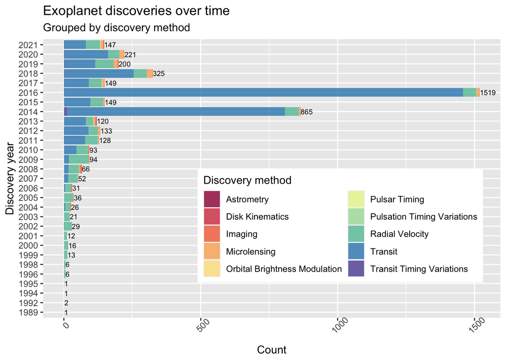

```r
# Retrieve latest exoplanet data
annualDiscoveries <- exoplanetData

# Create horizontal bar plot with annual number of discoveries
annualDiscoveryBar <- ggplot(annualDiscoveries, aes(x = as.character(disc_year)))
annualDiscoveryBar + geom_bar(aes(fill = discoverymethod),
                             alpha = 0.8, position = "stack") +
  labs(x = "Discovery year", y = "Count",
       title = "Exoplanet discoveries over time",
       subtitle = "Grouped by discovery method") +
  theme(axis.text.x = element_text(angle = 45)) +
  geom_text(stat="count", aes(label=..count..),
            vjust=0.5, hjust = -0.01, size = 2.5) +
  theme(legend.position = c(0.65, 0.33)) +
  # Split legend into two columns
  guides(fill=guide_legend(ncol=2)) +
  # Change color palette for bars based on
  # http://www.cookbook-r.com/Graphs/Colors_(ggplot2)/
  scale_fill_brewer(palette = "Spectral", name = "Discovery method") +
  coord_flip()
```

The contingency table below summarizes the cumulative number of observations for each discovery method.

```r
# Contingency table
# Total number of exoplanets found with each discovery method
discoveriesByMethod <- table(annualDiscoveries$discoverymethod)

# Display as data frame for aesthetics
knitr::kable(discoveriesByMethod,
             col.names = c("Discovery method", "Frequency"))
```

| Discovery method | Frequency |
| --- | --- |
| Astrometry | 1 |
| Disk Kinematics | 1 |
| Imaging | 45 |
| Microlensing | 113 |
| Orbital Brightness Modulation | 4 |
| Pulsar Timing | 6 |
| Pulsation Timing Variations | 2 |
| Radial Velocity | 870 |
| Transit | 3398 |
| Transit Timing Variations | 22 |

Of the known 4462 exoplanets, 76.2% were observed while transiting their host star and temporarily reducing its brightness. Another 19.5% were observed indirectly via the radial velocity method, whereby the planet and its star orbit around a common center of gravity and prompt noticeable Doppler shifts in the stellar spectrum.

```r
circumbinaryPlanets <- annualExoDiscoveries(cb_flag = 1)
circumbinaryPlanets
```

```
## # A tibble: 39 × 22
##    pl_name       disc_year discoverymethod   pl_orbper pl_rade pl_bmasse pl_radj
##    <chr>             <int> <chr>                 <dbl>   <dbl>     <dbl>   <dbl>
##  1 NSVS 1425682…      2019 Eclipse Timing V…     3225    12.3     4497.    1.1
##  2 RR Cae b           2012 Eclipse Timing V…     4344.   13       1335.    1.16
##  3 2MASS J19383…      2015 Eclipse Timing V…      416    13.4      604.    1.2
##  4 SR 12 AB c         2010 Imaging                 NA    12.3     4132.    1.1
##  5 MXB 1658-298…      2017 Eclipse Timing V…      760    12       7533.    1.07
##  6 Kepler-1647 b      2016 Transit               1108.   11.9      483     1.06
##  7 VHS J125601.…      2015 Imaging                 NA    12.4     3560.    1.11
##  8 2MASS J01033…      2013 Imaging                 NA    12.3     4132.    1.1
##  9 Kepler-453 b       2015 Transit                241.    6.20      16     0.553
## 10 Kepler-35 b        2011 Transit                131.    8.16      40.4   0.728
## # … with 29 more rows, and 15 more variables: pl_bmassj <dbl>, pl_eqt <dbl>,
## #   pl_dens <dbl>, st_spectype <chr>, st_teff <dbl>, st_lum <dbl>,
## #   pl_controv_flag <int>, pl_orbeccen <dbl>, pl_orbsmax <dbl>, st_mass <dbl>,
## #   st_metratio <chr>, st_met <dbl>, sy_snum <int>, sy_pnum <int>,
## #   luminosityRatio <dbl>
```

### Discovery methods

Each observation method excels in specific scenarios. The transit and radial velocity detection methods favor planets which orbit their star at an average distance of 0.12-1.6 AU.

```r
# Subset data to include only detection methods with a relatively large number
# of exoplanet discoveries
extendedDiscoveryProp <- exoplanetData
extendedDiscoveryProp <- extendedDiscoveryProp %>%
  filter(discoverymethod %in% c("Transit", "Radial Velocity", "Microlensing", "Imaging") &
           !is.na(pl_orbsmax))

# Display mean and median semi-major axes (in units of AU) for
# planets observed by these methods
discoverySummaries <- extendedDiscoveryProp %>% group_by(discoverymethod) %>%
  summarise(meanSMA = mean(pl_orbsmax), medianSMA = median(pl_orbsmax))
knitr::kable(discoverySummaries,
             col.names = c("Discovery method", "Mean SMA (AU)",
                           "Median SMA (AU)"))
```

| Discovery method | Mean SMA (AU) | Median SMA (AU) |
| --- | --- | --- |
| Imaging | 607.8113636 | 181.0000 |
| Microlensing | 2.6661518 | 2.2500 |
| Radial Velocity | 1.6044780 | 1.0200 |
| Transit | 0.1261318 | 0.0788 |

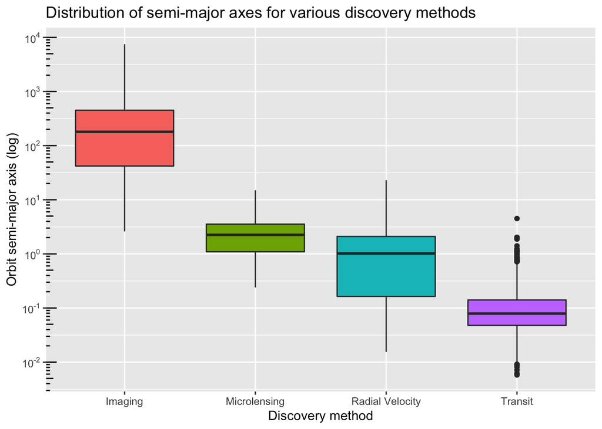

```r
orbsmaxBoxPlot <- ggplot(extendedDiscoveryProp,
                         aes(x = discoverymethod, y = pl_orbsmax,
                             fill = discoverymethod))
orbsmaxBoxPlot + geom_boxplot() +
  # Remove legend after coloration
  theme(legend.position = "none") +
  scale_y_log10(breaks = scales::trans_breaks("log10", function(x) 10^x),
   labels = scales::trans_format("log10", scales::math_format(10^.x))) +
  labs(x = "Discovery method", y = "Orbit semi-major axis (log)",
       title = "Distribution of semi-major axes for various discovery methods") +
  # Add log ticks to left side
  annotation_logticks(sides="l")
```

Direct imaging also favors young stars, which tend to be “self-luminous due to ongoing contraction and…accretion” (service), 2016). The combination of large semi-major axes and a luminous nature is generally attributed to giants that match or exceed the mass of Jupiter. This is corroborated by the scatter plot below, whereby the bulk of directly-imaged planets have a mass of approximately $10 M_{J}$ and reside at a distance of 10-10,000 astronomical units from their star.

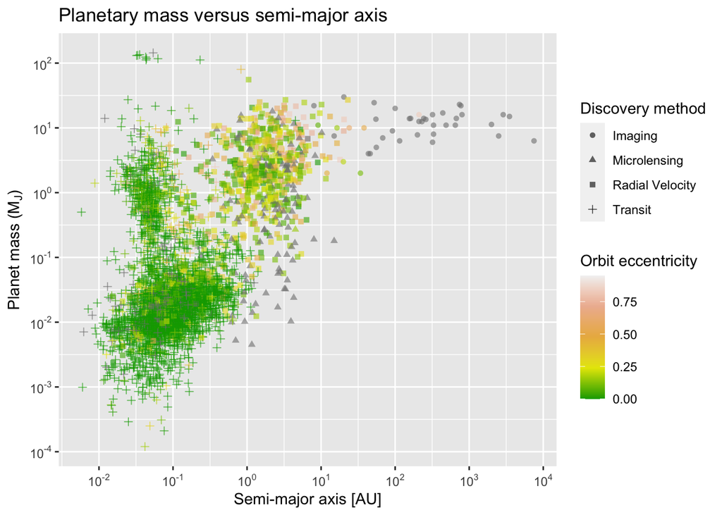

```r
# New vector with temporary data
orbsmaxMassData <- exoplanetData

# Scatter plot of masses/radii for discovered exoplanets
# Use LaTeX to denote the standard astronomical symbol for the Earth
orbsmaxMassScatter <- ggplot(extendedDiscoveryProp, aes(x = pl_orbsmax, y = pl_bmassj))
orbsmaxMassScatter + geom_point(aes(color = pl_orbeccen, shape = discoverymethod),
                                alpha = 0.6, position = "jitter") +
  scale_x_log10(breaks = scales::trans_breaks("log10", function(x) 10^x),
   labels = scales::trans_format("log10", scales::math_format(10^.x))) +
    scale_y_log10(breaks = scales::trans_breaks("log10", function(x) 10^x),
   labels = scales::trans_format("log10", scales::math_format(10^.x))) +
  # Select color palette for eccentricity from
  # https://rdrr.io/r/grDevices/palettes.html
  scale_color_gradientn(colours = terrain.colors(5)) +
  labs(x = "Semi-major axis [AU]", y = TeX(r'(Planet mass $(M_{J})$)'),
       title = "Planetary mass versus semi-major axis", col = "Orbit eccentricity",
       shape = "Discovery method")
```

### Metallicity correlations

We can observe at least one more obvious trend from the data - that of the “giant planet–metallicity correlation” - whereby giant planets “tend to appear around metal-rich stars” (Adibekyan, 2019). COonversely, “there is little or no dependence on metallicity for low-mass planets such as super-Earths” (Hasegawa & Pudritz, 2014). If we use $10 M \oplus$ as the threshold for super-Earths and create a histogram for the metallicity distribution of stars in the exoplanet database, we find that lanets with masses of $10 M \oplus$ or less are centered around stars with [Fe/H] = 0. On the other hand, giant plants (those which exceed $10 M \oplus$) exhibit a slightly right-skewed distribution with a substantial concentration near [Fe/H] = 0.13.

```r
metallicityData <- extendedDiscoveryProp %>% filter(st_metratio == "[Fe/H]" &
                                                      !is.na(pl_bmasse))
metallicityData %>% mutate(giantPlFlag = NA)
```

```
## # A tibble: 3,459 × 23
##    pl_name      disc_year discoverymethod pl_orbper pl_rade pl_bmasse pl_radj
##    <chr>            <int> <chr>               <dbl>   <dbl>     <dbl>   <dbl>
##  1 Kepler-276 c      2013 Transit             31.9     2.9      16.6    0.259
##  2 Kepler-829 b      2016 Transit              6.88    2.11      5.1    0.188
##  3 K2-283 b          2018 Transit              1.92    3.52     12.2    0.314
##  4 Kepler-477 b      2016 Transit             11.1     2.07      4.94   0.185
##  5 HAT-P-15 b        2010 Transit             10.9    11.9     617.     1.06
##  6 HD 149143 b       2005 Radial Velocity      4.07   13.6     423.     1.22
##  7 HD 210702 b       2007 Radial Velocity    354.     13.4     575.     1.2
##  8 HIP 12961 b       2010 Radial Velocity     57.4    13.2     114.     1.18
##  9 XO-5 b            2008 Transit              4.19   12.8     378.     1.14
## 10 HD 5608 b         2012 Radial Velocity    780.     13.5     534.     1.2
## # … with 3,449 more rows, and 16 more variables: pl_bmassj <dbl>, pl_eqt <dbl>,
## #   pl_dens <dbl>, st_spectype <chr>, st_teff <dbl>, st_lum <dbl>,
## #   pl_controv_flag <int>, pl_orbeccen <dbl>, pl_orbsmax <dbl>, st_mass <dbl>,
## #   st_metratio <chr>, st_met <dbl>, sy_snum <int>, sy_pnum <int>,
## #   luminosityRatio <dbl>, giantPlFlag <lgl>
```

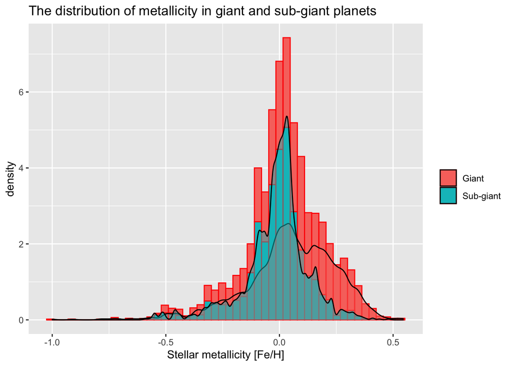

```r
for (i in 1:length(metallicityData$pl_name)){
  if (metallicityData$pl_bmasse[i] >= 10){
    metallicityData$giantPlFlag[i] = "Giant"
  } else if(metallicityData$pl_bmasse[i] < 10){
    metallicityData$giantPlFlag[i] = "Sub-giant"
  }
  else {
    metallicityData$giantPlFlag[i] = NA
  }
}

metallicityHisto <- ggplot(metallicityData, aes(x = st_met))
metallicityHisto + geom_histogram(aes(y = ..density..,
                                      fill = giantPlFlag),
                                  bins = 50, color = "red") +
  labs(x = "Stellar metallicity [Fe/H]",
       title = "The distribution of metallicity in giant and sub-giant planets",
       fill = "") +
  geom_density(adjust = 0.5, alpha = 0.5, aes(fill = giantPlFlag))
```

An empirical cumulative distribution function affirms that, while 50% of sub-giant ($M < 10 M \oplus$) planets orbit a star with a metallicity [Fe/H] = 0, 50% of giant planets ($M >= 10 M \oplus$) orbit stars with a metallicity of [Fe/H] = 0.06.

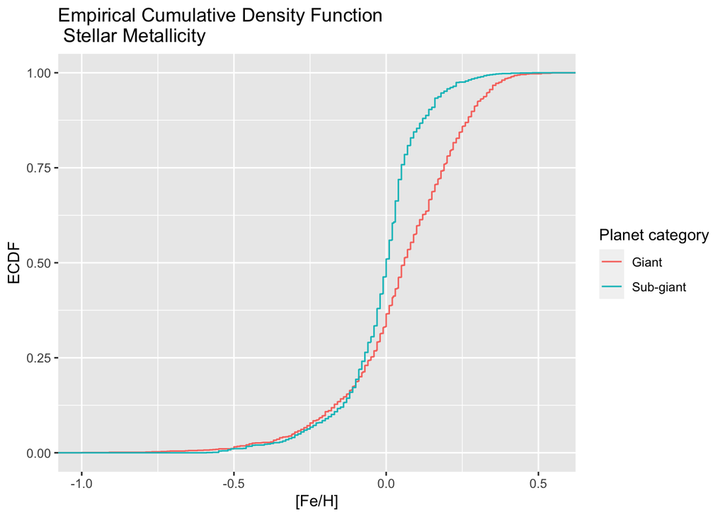

```r
# Render and label metallicity ECDF
metallicityHisto + stat_ecdf(geom = "step", aes(color = giantPlFlag)) +
  labs(title="Empirical Cumulative Density Function \n Stellar Metallicity",
     y = "ECDF", x="[Fe/H]", color = "Planet category")
```

```r
# Group data by planet status (giant/sub-giant) and calculate
# mean/median metallicity.
metallicityAverages <- metallicityData %>% group_by(giantPlFlag) %>%
  summarise(meanMetallicity = mean(st_met), medianMetallicity = median(st_met))
knitr::kable(metallicityAverages,
             col.names = c("Classification", "Mean stellar metallicity [dex]",
                           "Median stellar metallicity [dex]"))
```

| Classification | Mean stellar metallicity [dex] | Median stellar metallicity [dex] |
| --- | --- | --- |
| Giant | 0.0506846 | 0.06 |
| Sub-giant | -0.0131614 | 0.00 |

### Mass-radius diagram

Planets with radii in the range $10-15 R\oplus$ comprise 20% of our data set. The bulk of the remaining observations - more than 60% - consists of planets in the range of $0.1-5 R\oplus$.

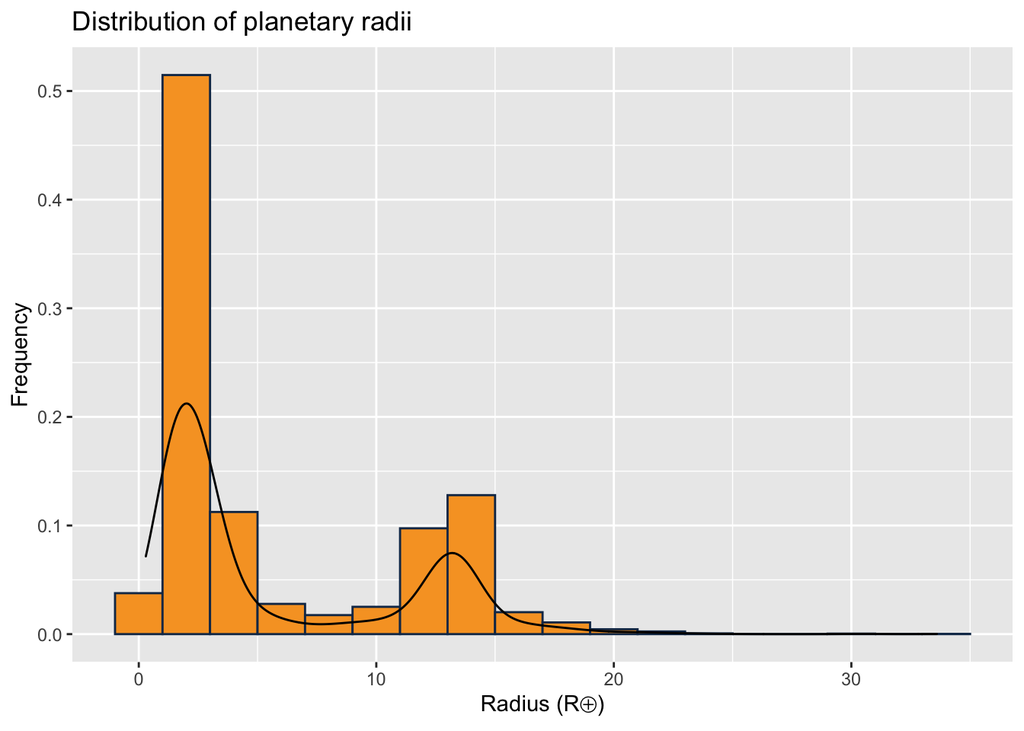

```r
radiiFreq <- ggplot(annualDiscoveries, aes(x = pl_rade))
radiiFreq + geom_histogram(color = "#123456", fill = "#f7a22b",
                           aes(y = (..count..)/sum(..count..)),
                           binwidth = 2) +
  labs(title="Distribution of planetary radii") +
  labs(x = TeX(r'(Radius $(R\oplus$))'),
       y = "Frequency") +
  geom_density()
```

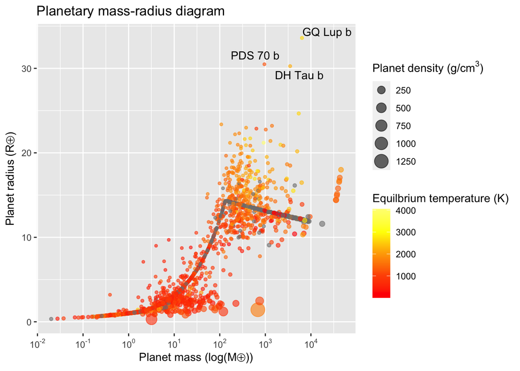

```r
# New vector with temporary data
tempMassData <- exoplanetData

# Scatter plot of masses/radii for discovered exoplanets
# Use LaTeX to denote the standard astronomical symbol for the Earth
tempMassScatter <- ggplot(tempMassData, aes(x = pl_bmasse, y = pl_rade))
tempMassScatter + geom_point(aes(col = pl_eqt, size = pl_dens), alpha = 0.6, position = "jitter") +
  scale_color_gradientn(colours = heat.colors(5)) +
  labs(x = TeX(r'(Planet mass $(log(M\oplus))]$))'), y = TeX(r'(Planet radius $(R\oplus)$)'),
       title = "Planetary mass-radius diagram", col = "Equilbrium temperature (K)",
       size = TeX(r'(Planet density $(g/cm^3)$)')) +
  # Label planets exceeding R = 25 (Earth), eliminate overlapping labels
  # using geom_text_repel from the ggrepel package
  geom_text_repel(aes(label = ifelse(pl_rade >= 25, pl_name,''))) +
  scale_x_log10(breaks = scales::trans_breaks("log10", function(x) 10^x),
   labels = scales::trans_format("log10", scales::math_format(10^.x)))
```

### Exoplanet habitability

Among the 4462 exoplanets in the NASA Exoplanet Archive, which have the potential to harbor life? The [Planetary Habitability Laboratory](http://phl.upr.edu/projects/habitable-exoplanets-catalog/methods) (PHL) attempts to answer this by narrowing conditions such that

1. “The planet orbits an F, G, K, or M star.”
2. “The planet orbits within the optimistic habitable zone defined by Kopparapu et al. (2014).”
3. “The planet has a radius between 0.5 to 2.5 Earth radii or a minimum mass between 0.1 to 10 Earth masses.”

Moreover, as defined by Zsom et al., “an exoplanet is habitable if liquid water, a crucial ingredient for life as we know it, is present on its surface, and if the surface temperature and pressure are such that complex organic molecules are stable” (Zsom et al., 2013). This this end, we can use criteria from the PHL and planetary equilibrium temperatures to compile our own list of potentially habitable exoplanets. We can then compare this list against one compiled by the PHL [Habitable Planets Catalog](http://phl.upr.edu/projects/habitable-exoplanets-catalog).

First, we calculate the maxima and minima for habitable zone distances and solar flux using formulae provided by Kopparapu et al. (Kopparapu et al., 2014). The `hzFluxCalculator()` function takes an existing data frame (such as the one produced by the `annualExoDiscoveries()` function) and appends to it the columns *innerHZ*, *outerHZ*, *innerFlux*, and *outerFlux*. Individual habitable zone values are calculated using the `calculateHZ()` function and extended to larger data sets via the `hzFluxCalculator()` function.

```r
# Exoplanet data from the NASA Exoplanet Archive
planetData <- exoplanetData

# Calculate maxima/minima for habitabilize zone distances
# and the solar flux incident on each exoplanet
planetData <- hzFluxCalculator(planetData)

head(planetData, n = 10)
```

```
## # A tibble: 10 × 27
##    pl_name         disc_year discoverymethod pl_orbper pl_rade pl_bmasse pl_radj
##    <chr>               <int> <chr>               <dbl>   <dbl>     <dbl>   <dbl>
##  1 OGLE-2016-BLG-…      2020 Microlensing        NA      13.9     250      1.24
##  2 GJ 480 b             2020 Radial Velocity      9.57    3.69     13.2    0.33
##  3 Kepler-276 c         2013 Transit             31.9     2.9      16.6    0.259
##  4 Kepler-829 b         2016 Transit              6.88    2.11      5.1    0.188
##  5 K2-283 b             2018 Transit              1.92    3.52     12.2    0.314
##  6 Kepler-477 b         2016 Transit             11.1     2.07      4.94   0.185
##  7 HAT-P-15 b           2010 Transit             10.9    11.9     617.     1.06
##  8 HD 149143 b          2005 Radial Velocity      4.07   13.6     423.     1.22
##  9 HD 210702 b          2007 Radial Velocity    354.     13.4     575.     1.2
## 10 HIP 12961 b          2010 Radial Velocity     57.4    13.2     114.     1.18
## # … with 20 more variables: pl_bmassj <dbl>, pl_eqt <dbl>, pl_dens <dbl>,
## #   st_spectype <chr>, st_teff <dbl>, st_lum <dbl>, pl_controv_flag <int>,
## #   pl_orbeccen <dbl>, pl_orbsmax <dbl>, st_mass <dbl>, st_metratio <chr>,
## #   st_met <dbl>, sy_snum <int>, sy_pnum <int>, luminosityRatio <dbl>,
## #   spectralClass <chr>, innerHZ <dbl>, outerHZ <dbl>, innerFlux <dbl>,
## #   outerFlux <dbl>
```

```r
# List habitable planets using "optimistic" parameters from
# Planetary Habitability Laboratory
listHabitablePlanets <- habitableExoFinder(planetData, minTemp = 181, maxTemp = 279,
                                           maxEarthMass = 10, maxEarthRadius = 2.5)
knitr::kable(listHabitablePlanets)
```

| pl_name | pl_eqt | spectralClass | pl_bmasse | pl_rade | pl_orbeccen | pl_orbsmax | innerHZ | outerHZ | innerFlux | outerFlux |
| --- | --- | --- | --- | --- | --- | --- | --- | --- | --- | --- |

Our combination of habitable zone distances, incident flux, effective temperatures, planet masses, and planet radii yield 0 potentially habitable exoplanets.

## References

Adibekyan, V. (2019). Heavy metal rules. I. Exoplanet incidence and metallicity. *Geosciences*, *9*(3). https://doi.org/10.3390/geosciences9030105

Hasegawa, Y., & Pudritz, R. E. (2014). PLANET TRAPS AND PLANETARY CORES: ORIGINS OF THE PLANET-METALLICITY CORRELATION. *The Astrophysical Journal*, *794*(1), 25. https://doi.org/10.1088/0004-637x/794/1/25

Hoolst, T. V., Noack, L., & Rivoldini, A. (2019). Exoplanet interiors and habitability. *Advances in Physics: X*, *4*(1), 1630316. https://doi.org/10.1080/23746149.2019.1630316

Kopparapu, R. K., Ramirez, R. M., SchottelKotte, J., Kasting, J. F., Domagal-Goldman, S., & Eymet, V. (2014). HABITABLE ZONES AROUND MAIN-SEQUENCE STARS: DEPENDENCE ON PLANETARY MASS. *The Astrophysical Journal*, *787*(2), L29. https://doi.org/10.1088/2041-8205/787/2/l29

Kuchner, M. J. (2003). Volatile-rich earth-mass planets in the habitable zone. *The Astrophysical Journal*, *596*(1), l105–l108. https://doi.org/10.1086/378397

NASA Exoplanet Science Institute. (2020). *Planetary systems composite table*. IPAC. https://doi.org/10.26133/NEA13

service), S. (Online. (2016). *Methods of detecting exoplanets 1st advanced school on exoplanetary science* (V. Bozza, L. Mancini, & A. Sozzetti, Eds.). Cham : Springer International Publishing : Imprint: Springer, 2016. https://catalog.lib.ncsu.edu/catalog/NCSU3603337

Zsom, A., Seager, S., Wit, J. de, & Stamenković, V. (2013). TOWARD THE MINIMUM INNER EDGE DISTANCE OF THE HABITABLE ZONE. *The Astrophysical Journal*, *778*(2), 109. https://doi.org/10.1088/0004-637x/778/2/109